# Introdução ao R

Alessandro Freire

15 novembro, 2019

## Baixando o R

- Acesse: https://www.r-project.org/
- Clique em “CRAN”, logo abaixo de “Download”, no canto esquerdo da página.
- Selecione um link do Brasil.
- Selecione a versão desejada (Windows, MAC ou Linux).
- Se estiver baixando pela primeira vez, selecione a opção “base”.

## Baixando o RStudio

- Acesse https://www.rstudio.com/products/rstudio/download/
- Selecione a opção gratuita.
- Pronto! Basta clicar no ícone da área de trabalho para iniciar o RStudio.

## Opções de Interface

O R possui mais de uma opção de interface. Sua versão padrão é bastante simples e praticamente não possui quaisquer atalhos com botões. Por outro lado, existem interfaces com mais opções e atalhos, o que pode facilitar a vida de quem nunca programou em R antes. A mais famosa delas é o RStudio.

## Opções de Interface (Padrão)

[figure not shown]

## Opções de Interface (RStudio)


## O Console

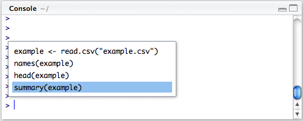

É onde os comandos podem ser digitados e os resultados desses mesmos comandos (exceto gráficos) são exibidos. Ainda que possamos eventualmente digitar comandos diretamente no console, é preferível não ter que repetí-los sempre que iniciarmos uma nova sessão no RStudio. Para isso, usamos o Editor de Scripts.

## O Editor de Scripts

[figure not shown]

É onde escrevemos e salvamos nossos códigos com os comandos que queremos executar. Usar um script é sempre mais recomendado para evitar repetições desnecessárias em análises. Além disso, o script permite que outras pessoas repliquem o seu trabalho.

Podemos adicionar comentários ao script usando o sinal de hashtag, de forma que fique mais claro para nós e para outras pessoas o que estamos fazendo.

```r
summary(cars) #Isto é um comentário, não um comando.
```

```
##      speed           dist
##  Min.   : 4.0   Min.   :  2.00
##  1st Qu.:12.0   1st Qu.: 26.00
##  Median :15.0   Median : 36.00
##  Mean   :15.4   Mean   : 42.98
##  3rd Qu.:19.0   3rd Qu.: 56.00
##  Max.   :25.0   Max.   :120.00
```

## O Ambiente Global

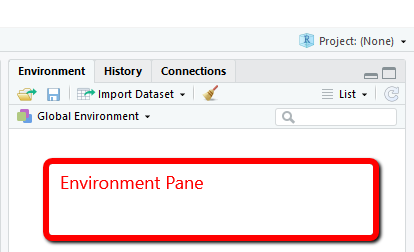

É onde ficam os objetos criados (vetores, dataframes, matrizes, listas, valores etc.). Uma das grandes vantagens do R é que, ao contrário de outros softwares como o SPSS ou o Stata, ele permite a utilização de várias básicos de dados simultaneamente, em uma mesma janela.

## O Painel de Arquivos

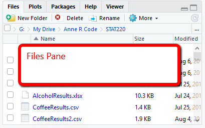

É onde são exibidos os gráficos, arquivos do ambiente de trabalho, pacotes e ajuda. Podemos ver informações sobre um pacote ou função na guia “Help” digitando “?” seguido do comando desejado:

```r
#?mean
```

## Abrindo e Salvando um Novo Script

Como vimos anteriormente, o uso de scripts é altamente recomendável. Para criarmos um novo script, podemos simplesmente clicar no ícone com uma cruz branca e um papel atrás logo abaixo de “File” no canto superior esquerdo da tela do RStudio. Após selecionarmos esse ícone, basta clicar em “R Script”.

Uma maneira mais rápida de abrir um novo script é usar atalhos no teclado. Em computadores com Windows basta digitar Ctrl + Shift + N para abrir um novo script. Para salvarmos nosso novo script, podemos clicar em “File” e, em seguida, em “Save as”. Uma forma mais rápida é usar o atalho Ctrl + S no teclado.

## Executando Comandos no Script

Para executar comandos no Script, basta selecionar a linha de comando desejada e clicar no botão “Run” na barra superior do script. Como somos programadores experientes, não usaremos o botão, mas sim o comando Ctrl + Enter.

## R como Calculadora

[figure not shown]

Antes de qualquer coisa, o R é uma calculadora. Experimente digitar os seguintes comandos no console, e aperte “Enter” em seguida, um a um.

```r
2 + 2 #Soma
```

```
## [1] 4
```

```r
7 - 2 #Subtração
```

```
## [1] 5
```

```r
2*3 #Multiplicação
```

```
## [1] 6
```

```r
9/3 #Divisão
```

```
## [1] 3
```

```r
2^4 #Potenciação
```

```
## [1] 16
```

```r
sqrt(64) #Raízes quadradas
```

```
## [1] 8
```

```r
log(10) #logaritmo
```

```
## [1] 2.302585
```

## Criando Objetos

Podemos criar objetos e salvá-los no ambiente global do R. Para isso, usamos o sinal `<-`. Isso significa que o R deve atribuir um deteminado valor a um objeto.

Por exemplo, digite o seguinte comando no console:

```r
a <- 3
```

Agora digite “a” e aperte “Enter”.

```r
a
```

```
## [1] 3
```

Agora veja o que acontece quando tentamos criar um objeto usando símbolos especiais ou iniciando-o com números.

```r
a@ <- 3
```

```
## Error: <text>:1:4: unexpected assignment
## 1: a@ <-
##        ^
```

```r
1a <- 3
```

```
## Error: <text>:1:2: unexpected symbol
## 1: 1a
##      ^
```

É importante destacar que nomes de objetos no R não podem ser inciados com números nem devem conter caracteres tais como #, @, ! e outros, uma vez que estes símbolos são usados em funções do R.

Podemos, contudo, adicionar números a nomes de objetos, contanto que não seja no início:

```r
a1 <- 4
```

```r
a.1 <- 5
```

Também podemos criar objetos com o resultado de operações ou de quaisquer funções de nosso interesse.

Por exemplo:

```r
a <- 3 + 2
a
```

```
## [1] 5
```

```r
b <- 8 - 4
b
```

```
## [1] 4
```

```r
c <- a + b
c
```

```
## [1] 9
```

```r
d <- sqrt(c)
d
```

```
## [1] 3
```

Também podemos usar a função `print()` quando quisermos exibir o resultado de um objeto, obtendo o mesmo resultado.

```r
print(a)
```

```
## [1] 5
```

```r
print(a+b)
```

```
## [1] 9
```

## Substituindo e Eliminando Objetos

Também é possível substituir ou eliminar objetos. Por exemplo, podemos digitar o seguinte comando para substituirmos o resultado do objeto “a”:

```r
a <- 12 - 3
a
```

```
## [1] 9
```

Agora o objeto “a” corresponde ao resultado de uma subtração, 9.

Finalmente, podemos eliminar um objeto por meio da função `rm()`. Experimente o seguinte comando:

```r
rm(a)
```

Veja o que acontece com o objeto “a” no ambiente global.

```r
a
```

```
## Error in eval(expr, envir, enclos): objeto 'a' não encontrado
```

# Vetores

Os vetores são dados armazenados em uma ordem específica. Por exemplo, suponha que tenhamos dados sobre o peso em kg de cinco pessoas. Podemos criar um vetor com esses dados usando a função `c()`, que concatena os dados digitados.

```r
peso_1 <- c(85, 96, 56, 68, 77)
peso_1
```

```
## [1] 85 96 56 68 77
```

Também podemos combinar diferentes vetores.

```r
peso_2 <- c(62, 81, 66, 70)
peso_2
```

```
## [1] 62 81 66 70
```

```r
peso_3 <- c(peso_1, peso_2)
peso_3
```

```
## [1] 85 96 56 68 77 62 81 66 70
```

Para selecionar elementos específicos de um vetor, basta utilizar o sinal de chaves `[]`. Por exemplo, se quisermos selecionar o segundo elemento do vetor “peso_1”, digitamos:

```r
peso_1[2]
```

```
## [1] 96
```

Podemos fazer operações com valores específicos de um vetor.

```r
peso_1[2]/4
```

```
## [1] 24
```

Também é possível excluir determinados valores de um vetor.

```r
peso_1
```

```
## [1] 85 96 56 68 77
```

```r
peso_1[-3]
```

```
## [1] 85 96 68 77
```

Embora os vetores sejam um dos mais simples tipos de objeto do R, o domínio de seu uso é extremamente importante. Quando começarmos a lidar com outros tipos de objetos, algumas operações serão muito semelhantes às que fizemos nos slides anteriores.

## Funções Básicas do R

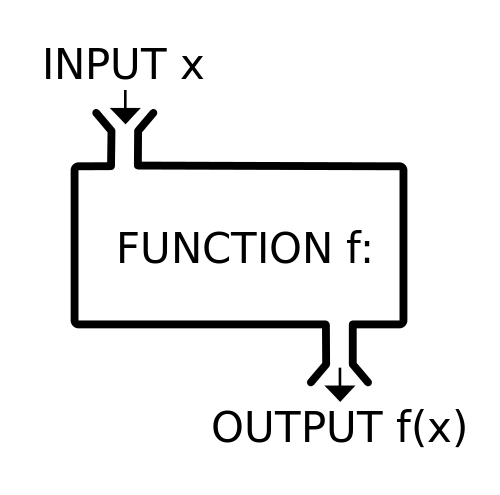

O R possui uma infinidade de funções, mas hoje começaremos com apenas algumas de suas funções mais básicas. Podemos descobrir o tamanho de um objeto com a função length():

```r
length(peso_1)
```

```
## [1] 5
```

Já as funções min() e max() nos dão os valores mínimo e máximo de um objeto, respectivamente.

```r
min(peso_1)
```

```
## [1] 56
```

```r
max(peso_1)
```

```
## [1] 96
```

A média, a variância e o desvio-padrão de um objeto são dados pelas funções mean(), var() e sd().

```r
mean(peso_2)
```

```
## [1] 69.75
```

```r
var(peso_2)
```

```
## [1] 66.91667
```

```r
sd(peso_2)
```

```
## [1] 8.180261
```

É importante lembrar que, caso haja dados faltantes (`NA`), o R não calculará as estatísticas acima, além de outras (como soma, mínimo e máximo, por exemplo) e nos retornará o valor `NA`. Nesses casos, devemos usar o argumento `na.rm = TRUE`, para que o R ignore os dados faltantes e faça os cálculos com base nas observações válidas.

```r
peso_1_NA <- c(85, 96, 56, 68, 77, NA)
mean(peso_1_NA) #Sem o argumento para remoção de NAs, o R nos retorna NA.
```

```
## [1] NA
```

Corrigindo:

```r
mean(peso_1_NA, na.rm = TRUE)
```

```
## [1] 76.4
```

Podemos criar uma sequência de números com a função seq(). Devemos incluir no parênteses os números inicial e final da sequência desejada, usando os argumentos “from” e “to”" para definí-los.

```r
seq(from = 1, to = 10)
```

```
##  [1]  1  2  3  4  5  6  7  8  9 10
```

Usando o argumento “by”, podemos definir o intervalo desejado na sequência. Por exemplo, se quisermos apenas os números pares de 2 a 30:

```r
seq(from = 2, to = 30, by = 2)
```

```
##  [1]  2  4  6  8 10 12 14 16 18 20 22 24 26 28 30
```

Também podemos obter a soma dos elementos de um objeto com a função sum().

```r
sum(peso_1)
```

```
## [1] 382
```

A função range() nos dá os valores mínimo e máximo de um objeto.

```r
range(peso_1)
```

```
## [1] 56 96
```

Podemos usar mais de uma função em um mesmo comando no R. Na verdade, podemos usar várias funções.

```r
sqrt(max(peso_1))
```

```
## [1] 9.797959
```

## Operadores lógicos ou booleanos

O R possui uma série de operadores lógicos os quais são bastante úteis em uma variedade de situações. É importante conhecê-los bem:

```r
4 == 4 #Igual a
```

```
## [1] TRUE
```

```r
4 > 5 #Maior que
```

```
## [1] FALSE
```

```r
7 != 6 #Diferente de
```

```
## [1] TRUE
```

```r
5 >= 5 #Maior ou igual a
```

```
## [1] TRUE
```

```r
4 <= 3 #Menor ou igual a
```

```
## [1] FALSE
```

```r
is.null(peso_1_NA) #É nulo
```

```
## [1] FALSE
```

```r
is.na(peso_1_NA) # É faltante
```

```
## [1] FALSE FALSE FALSE FALSE FALSE  TRUE
```

Note que o R nos retorna os resultados `TRUE` ou `FALSE` dependendo se a condição foi ou não foi satisfeita, respectivamente. Por exemplo, 4 é igual a 4, então o R nos retorna `TRUE`, porém 4 não é menor ou igual a 3, então o R nos retorna `FALSE`. Esses operadores serão usados com muita frequência quando estivermos manipulando bases de dados no R.

## Definindo um diretório de trabalho

Podemos obter o diretório de trabalho (a pasta a partir da qual o R carrega e salva arquivos) atual do R usando a função `getwd()`.

```r
getwd()
```

```
## [1] "C:/Users/Alessandro Freire/Dropbox/R"
```

Caso queiramos alterar o diretório de trabalho, usamos a função `setwd()`. É importante notar que devemos editar as barras do endereço do diretório em relação ao padrão do Windows, o qual é `\`:

```r
setwd("C:/Users/Alessandro Freire/Downloads")
```

ou então usamos duas barras `\\`:

```r
setwd("C:\\Users\\Alessandro Freire\\Downloads")
```

## Instalando e carregando pacotes

Para utilizarmos funções no R, devemos instalar e carregar pacotes (caso não façam parte do R básico). Para instalação utilizamos o comando `install.packages()` e para carregamento utilizamos o comando `library()`. É importante lembrar que não basta que um pacote esteja instalado no R para que possamos utilizar suas funções, mas também é preciso carregá-lo. Note que incluímos aspas no nome do pacote desejado ao usarmos a função `install.packages()`.

```r
install.packages("dplyr") #Instalando
library(dplyr) #Carregando
```

## Visualizando dados

Em geral, não visualizamos planilhas ao manipularmos dados no R. Entretanto é possível observar uma parte de um banco de dados com a função `head()`.

```r
head(mtcars)
```

```
##                    mpg cyl disp  hp drat    wt  qsec vs am gear carb
## Mazda RX4         21.0   6  160 110 3.90 2.620 16.46  0  1    4    4
## Mazda RX4 Wag     21.0   6  160 110 3.90 2.875 17.02  0  1    4    4
## Datsun 710        22.8   4  108  93 3.85 2.320 18.61  1  1    4    1
## Hornet 4 Drive    21.4   6  258 110 3.08 3.215 19.44  1  0    3    1
## Hornet Sportabout 18.7   8  360 175 3.15 3.440 17.02  0  0    3    2
## Valiant           18.1   6  225 105 2.76 3.460 20.22  1  0    3    1
```

O padrão da função `head()` é exibir as seis primeiras observações de um banco de dados. Entretanto, podemos aumentar ou diminuir esse número. Por exemplo, se quisermos as primeiras dez observações do banco de dados `mtcars` podemos digitar:

```r
head(mtcars, 10)
```

```
##                    mpg cyl  disp  hp drat    wt  qsec vs am gear carb
## Mazda RX4         21.0   6 160.0 110 3.90 2.620 16.46  0  1    4    4
## Mazda RX4 Wag     21.0   6 160.0 110 3.90 2.875 17.02  0  1    4    4
## Datsun 710        22.8   4 108.0  93 3.85 2.320 18.61  1  1    4    1
## Hornet 4 Drive    21.4   6 258.0 110 3.08 3.215 19.44  1  0    3    1
## Hornet Sportabout 18.7   8 360.0 175 3.15 3.440 17.02  0  0    3    2
## Valiant           18.1   6 225.0 105 2.76 3.460 20.22  1  0    3    1
## Duster 360        14.3   8 360.0 245 3.21 3.570 15.84  0  0    3    4
## Merc 240D         24.4   4 146.7  62 3.69 3.190 20.00  1  0    4    2
## Merc 230          22.8   4 140.8  95 3.92 3.150 22.90  1  0    4    2
## Merc 280          19.2   6 167.6 123 3.92 3.440 18.30  1  0    4    4
```

A função `tail()` permite a visualização das **últimas** observações de um banco de dados. Assim como na função `head()` também podemos aumentar ou diminuir o número de observações.

```r
tail(mtcars, 10)
```

```
##                   mpg cyl  disp  hp drat    wt  qsec vs am gear carb
## AMC Javelin      15.2   8 304.0 150 3.15 3.435 17.30  0  0    3    2
## Camaro Z28       13.3   8 350.0 245 3.73 3.840 15.41  0  0    3    4
## Pontiac Firebird 19.2   8 400.0 175 3.08 3.845 17.05  0  0    3    2
## Fiat X1-9        27.3   4  79.0  66 4.08 1.935 18.90  1  1    4    1
## Porsche 914-2    26.0   4 120.3  91 4.43 2.140 16.70  0  1    5    2
## Lotus Europa     30.4   4  95.1 113 3.77 1.513 16.90  1  1    5    2
## Ford Pantera L   15.8   8 351.0 264 4.22 3.170 14.50  0  1    5    4
## Ferrari Dino     19.7   6 145.0 175 3.62 2.770 15.50  0  1    5    6
## Maserati Bora    15.0   8 301.0 335 3.54 3.570 14.60  0  1    5    8
## Volvo 142E       21.4   4 121.0 109 4.11 2.780 18.60  1  1    4    2
```

Também podemos visualizar todo um banco de dados, como em uma planilha Excel, usando a função `View()`:

```r
View(mtcars)
```

## Encerrando uma sessão no R

Para encerrar uma sessão no R, basta digitar o seguinte comando:

```r
quit()
```

Ou simplesmente:

```r
q()
```

# (Não) Salvando o workspace

É importante lembrar que, via de regra, NÃO devemos salvar o ambiente de trabalho ao encerrarmos o R. Isso porque queremos evitar que erros em uma sessão acabem sendo salvos. Por exemplo, você poderia acidentalmente executar um comando deletando uma variável de sua base de dados e isso seria salvo permamentemente. Dessa forma, NÃO salve o seu workspace ao encerrar uma sessão no R, exceto em circustâncias muito específicas.

# Exercícios

1) Para os exercícios abaixo, crie um script, salve-o com o nome `ìntro_r` e todos os comandos dos exercícios nele. Lembre-se dos atalhos do teclado para criar e salvar o seu script. Nada de clicar em botões!

2) A tabela abaixo exibe o consumo médio de combustível (mpg) e a potência do motor (hp) de 5 carros. Construa dois vetores chamados “consumo” e “potencia” com os dados exibidos na tabela.

Tabela 1

|  | mpg | hp |
| --- | --- | --- |
| Mazda RX4 | 21.0 | 110 |
| Mazda RX4 Wag | 21.0 | 110 |
| Datsun 710 | 22.8 | 93 |
| Hornet 4 Drive | 21.4 | 110 |
| Hornet Sportabout | 18.7 | 175 |

3) Calcule a média e o desvio-padrão do consumo e da potência dos carros. Salve os resultados criando objetos denominados “media_consumo”, “dp_consumo”, “media_potencia” e “dp_potencia”.

4) Selecione o segundo elemento do vetor “consumo” e calcule a sua raiz quadrada. Salve o resultado em um objeto chamado “consumo_raiz”.

5) Crie um novo vetor de consumo denominado “novo_consumo” removendo o dado do quarto carro. Remova o dado de potência do primeiro carro e crie um novo vetor chamado “novo_potencia”. Calcule as médias dos novos vetores e salve os resultados como “media_novo_consumo” e “media_novo_potencia”.

6) Calcule a soma dos números pares de 2 a 268. Salve o resultado em um objeto chamado “soma_pares”. Calcule a soma dos números ímpares de 1 a 251. Salve o resultado em um objeto chamado “soma_impares”.

7) Instale e carregue o pacote `gapminder`. Visualize as seis primeiras observações da base de dados `gapminder`. Qual a população (variável `pop`) do Afeganistão em 1952?